# SMI106 computer lab week 4

Dan Olner

# Quick recap on RStudio projects and working directories

Just to go over why I’ve been suggesting using **projects in RStudio**.

Your **working directory** (a directory is just a folder location) is the place that R looks for **relative file paths** to your code and data. With your working directory set, it means you could use code like this to load data (assuming the CSV is in a subfolder called ‘data’ in the top level of your working directory):

> **You don’t need to run this code yourself, they’re just examples**

```r
x <- read.csv('data/basque.csv')
```

**Without having the working directory set like this, you’d need the full file path.** In my case it looks like this. It’s not pretty.

```r
x <- read.csv('C:/Users/admin/Dropbox/SheffieldMethodsInstitute/Teaching/SMI106/SMI106_R/data/basque.csv')
```

> Note the structure here: **all file systems have this same nested structure where any path is a series of nested folders, usually starting right at the root of the hard drive. (My hard drive’s referenced with “C” here.)**

In R, you can see what your **current working directory is set to using the `getwd()` function**. As you can see here, mine is currently all of the above file path before `data`.

```r
getwd()
```

```
## [1] "C:/Users/admin/Dropbox/SheffieldMethodsInstitute/Teaching/SMI106/SMI106_R"
```

That path is **where R is expecting files to be**. At that location, you can **also have subfolders** (like the `data` folder above), but a subfolder reference like `data/basque.csv` will **only work if the working directory is set correctly**.

You *can* set the working directory with `setwd()’ - but a nice self-contained way around this is to **use RStudio projects**. In a project, the working directory is set for you **to the project folder**. This allows other helpful things to occur, like file path autocomplete, seeing all your files in the files pane etc. It also means it can easily be moved from place to place, making it more reproducible.

Note the following:

- **If in the top-right of your RStudio window, it says `Project (None)’ (as below) then you do *not* have an RStudio project open.**

[figure not shown]

- If in the top-right the window, it has a folder name like this, then you have a project open, with that folder as the root for all file paths.

[figure not shown]

- If you are using `Project (None)`, then the **default folder for that** is set via Tools/Global options/General, and the *default working directory (when not in a project) option. Though, as mentioned, you could also set with `setwd()`.

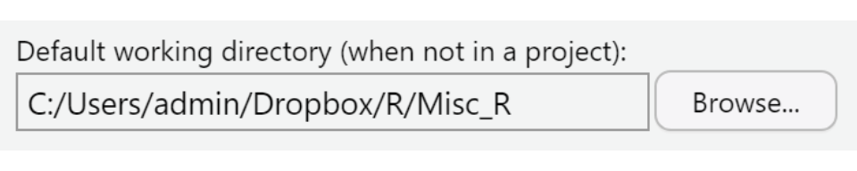

You’ve seen the options available in the `project` menu:

[figure not shown]

Here you can:

- Create a new project, either using an existing folder, or make a new folder
- Open a previously created project
- Your most recently used projects will be here too
- Close the project

If you want to get back to the files you had open before making a project, just **close the project** and you’ll **return to `Project(None)`**, with all those files.

Note: you can also **open a project in new session** or **go to session / new session in the menu**. This will make an entirely new **RStudio window**, if you want to have more than one window running at the same time. (In case you want your `Project(None)` work visible while also working in a project folder.)

Another note: one exception to all this is **RMarkdown scripts**:

- **By default, the working directory for RMarkdown scripts is whichever folder the RMarkdown script is run from.** Worth noting in case you get strange errors running an RMarkdown script where it can’t find the data. As long as you put them in the root of your working directory, it’ll work as the rest of your code does.

**If all of that seems confusing, that’s a reasonable reaction! Working directory stuff takes a while getting used to working with directly in code.**

# Quick recap on vectors, dataframes and arithmetic on dataframes

A quick recap on how arithmetic works on dataframe columns. If we make a simple example dataframe with two columns, like this… first, make two vectors, then put each of those into the `data.frame` function to make a dataframe.

```r
x <- c(2,4,6,8,10)

y <- c(3,6,9,12,15)

df <- data.frame(col1 = x, col2 = y)
```

Note, we could also have just set those numbers directly in the dataframe function if we wanted to:

```r
df <- data.frame(
  col1 = c(2,4,6,8,10),
  col2 = c(3,6,9,12,15)
  )
```

We can check in the environment panel that our new `df` dataframe has been created. This is the same thing we’d get if we loaded in a **csv** file of the same data.

To multiply the two columns, row-wise, we just do the following:

```r
df$col1 * df$col2
```

That outputs to the console. If we want to assign it to a **new column in the same dataframe**, we just make up a new column name and assign the same line:

```r
df$newcol <- df$col1 * df$col2
```

# Vietnam draft lottery: did it have any effect on political attitudes?

These exercises are based on the following paper:

Green, Donald P., Tiffancy C. Davenport, and Kolby Hanson (2019). “[Are There Long-Term Effects of the Vietnam Draft on Political Attitudes or Behavior? Apparently Not.](https://doi.org/10.1017/XPS.2018.18)” *Journal of Experimental Political Science.* 6(2), 71-80.

This paper examines the long-term effects of the Vietnam draft lottery on the political attitudes and behavior of the men who were were eligible for the draft during the period of 1969–1971. Based on birth dates, the draft lottery was used to randomly select men who turned 19 prior to 1969, 1970 and 1971 to serve in the US army. While many of those selected did not eventually serve, the authors use a survey and publicly available information, such as voter registration, voter records and partisan membership of eligible draftees to study whether being *assigned* to the draft has any long-term political effects (based on surveying these men’s political attitudes in 2014-16).

The data set `survey.csv` contains the following variables.

| Name | Description |
| --- | --- |
| `draft` | Whether a respondent was drafted (`1`) or not (`0`) |
| `year` | Birth year |
| `ideology` | Ideology score that takes values from 1 to 5 where 1 is “very conservative,” 3 is “moderate,” and 5 is “very liberal.” |
| `state` | Respondent’s living state |

# 1: load the data into a dataframe and inspect it

Load the data and check the data with the `summary()` function. Which variable (column) has a missing data? Also, check the number of observations (including the missing values).

You can **either** use this code to directly load the data from the internet:

```r
data <- read.csv(url('https://bit.ly/smi106draft'))
```

**Or** download the CSV from this week’s Blackboard and move to your project folder / working directory and use `read.csv` in the usual way.

Then **use the summary function** to look at the data:

```r
summary(data)
```

Now, we want to know three things:

- How many respondents there are in the data?
- How many different US states does the data contain? (We’ll use that in a bit.)
- How many people are in each of the five ideology levels?

The number of respondents is **just the same as the number of rows in the data**. There are (at least) **two ways** to find this. You can:

- Look at the number of ‘obs’ (observations) in the environment panel for the dataset you loaded in.
- Or just use the `nrow` function:

```r
nrow(data)
```

```
## [1] 660
```

> Note: it isn’t always the case that each row is one respondent. Sometimes a single respondent to survey, say, will appear in multiple rows if factors for that respondent appear more than once. But if there’s nothing else to indicate otherwise, generally one row is one respondent.

To find the number of different American states in the data, we can use the `unique` function, in combination with the `length` function. Let’s do each of those separately to see what they do.

The `unique` function gives us just the individual, unique values in any column or vector:

```r
unique(data$state)
```

```
## [1] "CO" "OR"
```

So here we only have **two unique US states** (these are codes for Colorado and Oregon.) You can see there are only two, but if we wanted to check the length of that vector in code, we’d do this:

```r
length(unique(data$state))
```

```
## [1] 2
```

So there are **only two US states in the data**.

The ideology score in the data is in **integers**: it only takes round values from 1 to 5. So we can use `table` to count how many respondents have each ideology score. Recall that 1 is “very conservative,” 3 is “moderate,” and 5 is “very liberal”.

```r
table(data$ideology)
```

```
##
##   1   2   3   4   5
##  44 161 242 146  67
```

# 2. Creating new variables based on existing ones

Very often we’ll want to process existing columns and create new ones with different categories. As always, there are several ways of doing this, but let’s look at a couple.

What if we want to create a **two level ideology category** that is just **conservative** and **other**? Assuming that values 1 and 2 are conservative (where 1 is “very conservative” and 2 is just “conservative”), we could use the following approach:

- **Create a new binary variable named “conservative” that marks those in ‘category 1 and 2’ as 1 and the rest as zero.**

First, we want to work out what **logical operators** we’re using here. Reminder of what logical operators we can use:

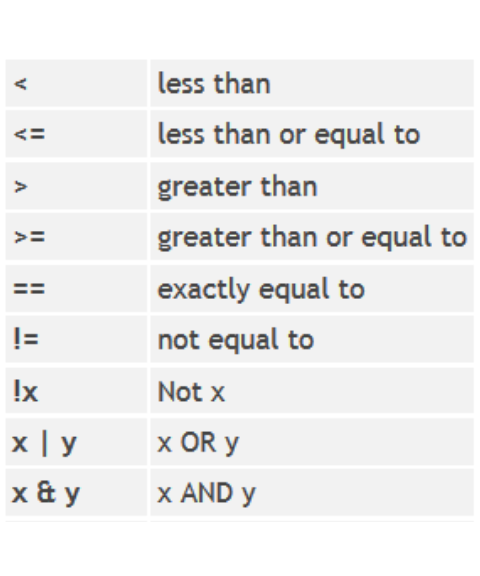

Note the two at the bottom, `AND` & `OR` (along with `NOT`, sometimes known as the relational operators). If we want to know whether the ideology vector **contains a 1 OR a 2**, we could do this. The bar symbol represents `OR`.

```r
data$ideology == 1 | data$ideology == 2
```

There is another way to do this, which can be tidier sometimes, if you are asking ‘does this vector contain x OR y OR z OR a OR b’ etc. Here, we’re only doing this with two values, but the principle is the same. We can ask instead, **are the values in this vector %in% this other vector**?

```r
data$ideology %in% c(1,2)
```

OK. Now we have that, we can use it to create a new column. We’ve done this directly before, but a nice function to do this with is `ifelse`. This will set a column to one of two values, depending on if our condition is TRUE or FALSE:

```r
ifelse(test = data$ideology %in% c(1,2), yes = 1, no = 0)
```

We can choose whatever we want for the “yes” and “no”. We could use text if we wanted. For example:

```r
ifelse(test = data$ideology %in% c(1,2), yes = "conservative", no = "not conservative")
```

But let’s stick to 1 and 0 and use those to create the new column. Note here also - another reminder: **if you pass arguments into a function in the correct order (the order they appear in their help file) you don’t need to name them**. So we can do this:

```r
data$isconservative <- ifelse(data$ideology %in% c(1,2), 1, 0)
```

You can see A useful feature of vectors with just 1s and 0s if we just look at an example. Let’s make a little vector with two ones and two zeroes:

```r
x <- c(1,1,0,0)
```

**The mean of this vector gives us the proportion of ones** (50% ones):

```r
mean(x)
```

```
## [1] 0.5
```

Note that R will treat TRUE and FALSE vectors the same as 1 and 0 when finding means, so you can also find proportions e.g. of:

```r
y <- c(TRUE, TRUE, FALSE, FALSE)
mean(y)
```

```
## [1] 0.5
```

So we can do this with **any vector of ones and zeroes (or vector of TRUE and FALSES)** to find a proportion of some binary variable. So -

> **Exercise: using our newly created data$isconservative column, find the proportion of conservatives in this dataset. (Multiply by a hundred to get the percentage.)**

# 3. Rescaling a variable so it’s between 0 and 1 (sometimes known as *normalising*)

As we’ve seen, the `ideology` variable is between 1 and 5. Oftentimes, it’s useful to scale variables like this so they’re between 0 and 1. This allows us to talk about change in that variable in proportion or percentage terms (e.g. “x has shifted 35% toward the liberal end of the ideology scale”).

The general formula for scaling any numeric vector to between 0 and 1 looks like this:

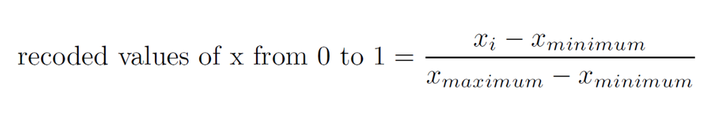

If we were to apply this to the `ideology` column, it would look like this, using R’s `min` and `max` functions. **Note how we use brackets to make sure each part of the calculation is done correctly**. It’s also always worth spacing brackets out when you’re writing this kind of thing, as it makes it *much* easier to read while coding:

```r
( data$ideology - min(data$ideology) ) / ( max(data$ideology) - min(data$ideology) )
```

And as usual, if we want to store this as a variable that’s part of the original dataframe, we just assign it:

```r
data$ideology_scaled <- ( data$ideology - min(data$ideology) ) /
  ( max(data$ideology) - min(data$ideology) )
```

We can use `summary` to confirm our new column `ideology_scaled` is between zero and 1:

```r
summary(data)
```

Given that, we could now ask **by what percentage do ideology scores differ in the two US states in the data?** We could use **subsetting within square brackets** as one way to do this:

```r
mean(data$ideology_scaled[data$state=="CO"])#Colorado
```

```
## [1] 0.4765343
```

```r
mean(data$ideology_scaled[data$state=="OR"])#Oregon
```

```
## [1] 0.5372063
```

> **EXERCISE: What’s the percentage point difference ideology score between Colorado and Oregon? By how many *percentage points* is one more liberal than the other?** Note: if you want to multiply your difference calculation by 100 to get a percentage, **be sure to put the difference calculation in brackets**. (See what happens if you don’t.)

Note what we did there: subset the dataset into two groups, one each for ‘CO’ and ‘OR’. And then found the mean of each subgroup. **We’ve seen in previous weeks how the `tapply` function can do the same.** `tapply` will (a) take in the vector you want to break into subgroups; (b) take another vector that contains the groups you want to break it down by; (c) apply a function to each of those subgroups.

So we could achieve the same thing as above with:

```r
tapply(data$ideology_scaled, data$state, mean)
```

```
##        CO        OR
## 0.4765343 0.5372063
```

And subtract each part by keeping the output of tapply and using the usual **square bracket index reference** to pick out each result:

```r
groupcalc <- tapply(data$ideology_scaled, data$state, mean)

groupcalc[2]-groupcalc[1]
```

```
##         OR
## 0.06067197
```

```r
#In percentage point terms:
(groupcalc[2]-groupcalc[1])*100
```

```
##       OR
## 6.067197
```

Finally, let’s **find out if there is a difference in ideology (using our `ideology_scaled` variable) between people who were drafted and those who weren’t.** Let’s look at what number of people in the dataset were drafted:

```r
table(data$draft)
```

```
##
##   0   1
## 316 344
```

> **EXERCISE: find the difference in (scaled) ideology, in percentage points, between those drafted and those not drafted.**

All we need to do here:

- Find the mean of each subset of `ideology_scaled`, for `draft == 1` and `draft == 0`
- That can *either* be be done by subsetting directly, so e.g. taking the `data$ideology_scaled` column and, in the square brackets, subsetting by a match to `data$draft == 1` or `data$draft == 0`
- Or using `tapply` as we did above.
- Subtract these means to get the difference. (Note: it’s best to look at what values the two means take to make sure you know what the polarity of the result means.)
- Multiply that result by 100 to convert to percentage points

**What’s the percentage point difference? Do we think this is a difference worth noting?**

# 4. Difference in difference (also known as difference in differences)

Let’s work through the **Basque example from the lecture**, to make sure we know how to run *differenece in difference* code and what it means.

As before, you can **either** load the CSV directly into a dataframe from the internet:

```r
basque <- read.csv(url('https://bit.ly/smi106basque'))
```

Or download a copy of the CSV from Blackboard and move to your RStudio project folder or working directory, then load into a dataframe using the usual `read.csv` function.

Use the summary function to look again at what variables are contained in the dataset:

```r
summary(basque)
```

```
##   regionname             year          gdpcap
##  Length:731         Min.   :1955   Min.   : 1.243
##  Class :character   1st Qu.:1965   1st Qu.: 3.685
##  Mode  :character   Median :1976   Median : 5.283
##                     Mean   :1976   Mean   : 5.397
##                     3rd Qu.:1987   3rd Qu.: 6.868
##                     Max.   :1997   Max.   :12.350
```

We can look at the regions in the dataset using, again, the unique function (and length to find how many unique regions there are):

```r
unique(basque$regionname)
```

```
##  [1] "Andalucia"                    "Aragon"
##  [3] "Principado De Asturias"       "Baleares (Islas)"
##  [5] "Canarias"                     "Cantabria"
##  [7] "Castilla Y Leon"              "Castilla-La Mancha"
##  [9] "Cataluna"                     "Comunidad Valenciana"
## [11] "Extremadura"                  "Galicia"
## [13] "Madrid (Comunidad De)"        "Murcia (Region de)"
## [15] "Navarra (Comunidad Foral De)" "Basque Country (Pais Vasco)"
## [17] "Rioja (La)"
```

```r
length(unique(basque$regionname))
```

```
## [1] 17
```

The question we want to ask:

- **Did Basque terrorism have a causal impact on the economy of the Basque Country?**

We saw in the lecture that doing these two things doesn’t give us much insight into this question:

- Comparing the Basque country to other regions at the same time point after the terrorist period (**cross-sectional comparison**)
- Seeing how the Basque country itself changed before and after (**before and after analysis**)

Instead, we want to know:

- How does the Basque country economy’s change over time **compare to** other regions’ change over time?

For our causal inference, we make a strong assumption:

- Our **counterfactual** is that, in the absence of terrorism, the Basque country’s change over time **would have had the same slope as the other regions’**.

We can summarise this idea graphically:

- The `treatment` line is mean Basque GDP before and after
- The `control` line is the mean for other regions GDP before and after
- The `counterfactual` in blue is the line that we’re claiming the Basque country **would have taken in the absence of terrorism**.

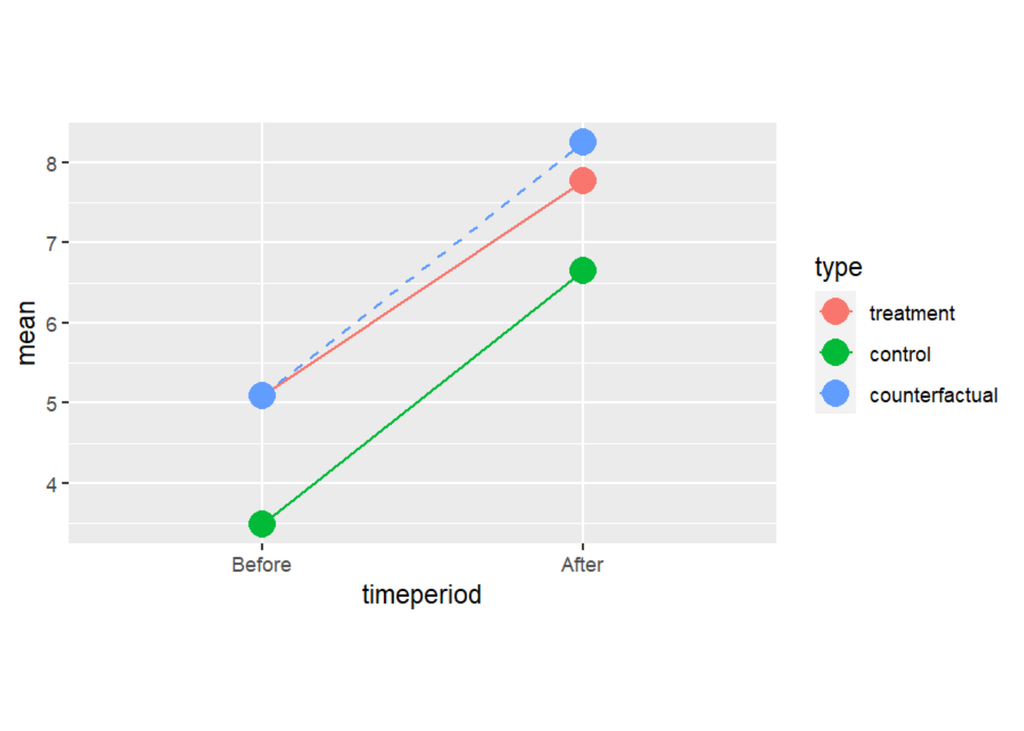

We find all these points by finding the **means** for both the *treatment* and *control*, and for *each time point*. We split the time points at 1973, so *before* is before there was any terrorism in the Basque country:

```r
#Basque country BEFORE terrorism
treatedBefore <- subset(basque, year < 1973 & regionname == "Basque Country (Pais Vasco)")

#Basque country AFTER terrorism
treatedAfter <- subset(basque, year >= 1973 & regionname == "Basque Country (Pais Vasco)")

#Other Spanish regions BEFORE terrorism
controlBefore <- subset(basque, year < 1973 & regionname != "Basque Country (Pais Vasco)")

#Other Spanish regions AFTER terrorism
controlAfter <- subset(basque, year >= 1973 & regionname != "Basque Country (Pais Vasco)")
```

We can then use these to find the **difference in difference**, which is the gap marked in green here, where you can see the actual Basque GDP number is **slightly lower** than the counterfactual parallel slope:

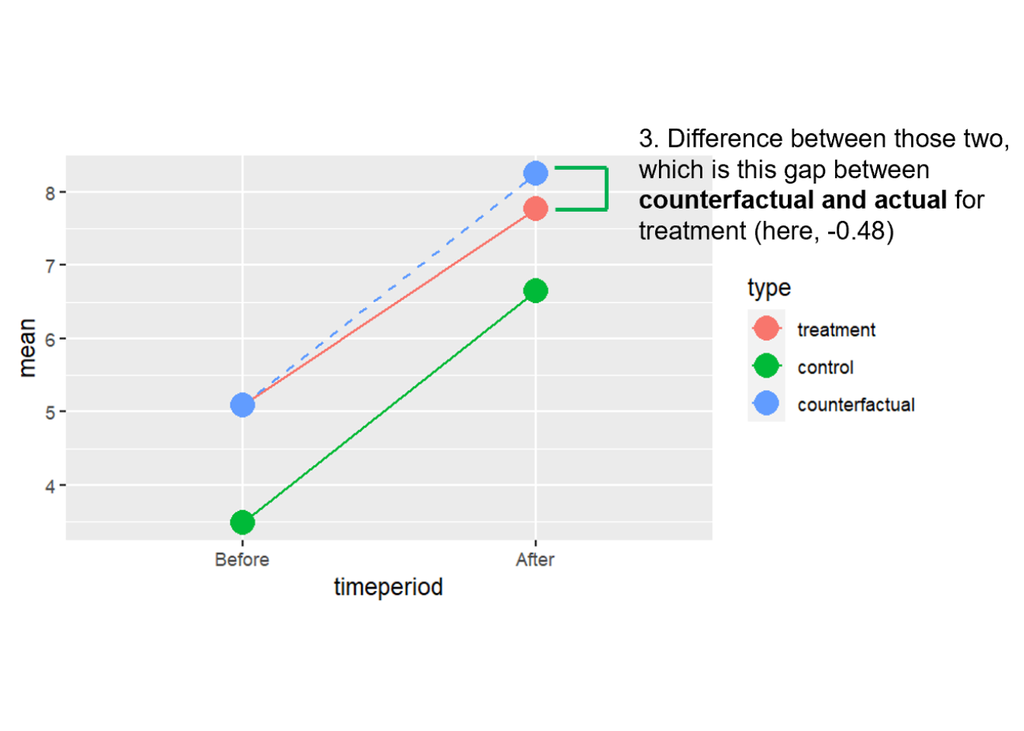

That’s done in **three stages.**:

```r
#1. Difference in mean Basque GDP per capita BEFORE vs AFTER
treatDiff <- mean(treatedAfter$gdpcap) - mean(treatedBefore$gdpcap)

#2. Difference in other regions' mean GDP per capita BEFORE vs AFTER
controlDiff <- mean(controlAfter$gdpcap) - mean(controlBefore$gdpcap)

#3. Difference in difference
#-0.48, so 0.48 LOWER mean GDP per capita in the Basque country
#than would be expected WITHOUT terrorism
#(the difference between where the parallel slopes assumption line ends
#and the actual GDP level in Basque country)
treatDiff - controlDiff
```

```
## [1] -0.48316
```

> A final diff-in-diff value of =0.48, so as the code comments say: **0.48 LOWER mean GDP per capita in the Basque country than would be expected WITHOUT terrorism.**

# 3a. Creating your own functions

Let’s return now to the Vietnam lottery data to cover one more topic.

R is a **functional** programming language. As Hadley Wickham says, “It lends itself to a style of problem solving centred on functions.” We’ve been using these a lot already - `mean`, `tapply` etc. All functions are **just input output machines**:

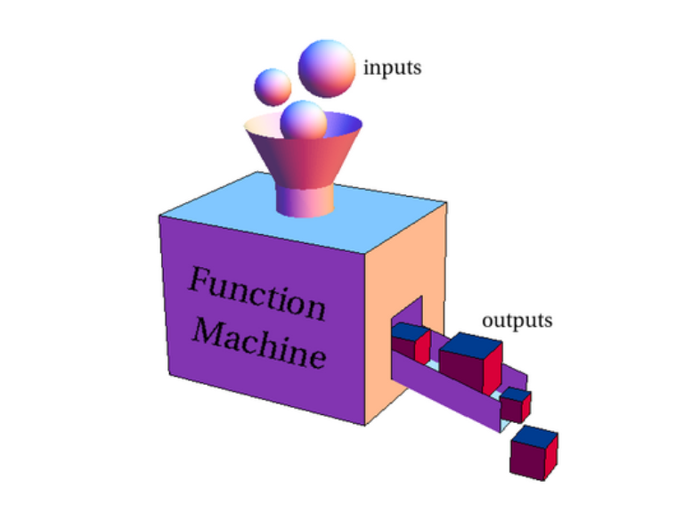

They all follow the same format in R:

1. You **input** one or more **arguments**
2. The function **outputs** some value or object that has processed those inputs

We also saw above how you can either **fully name all the arguments going into the function**. For example, if we fully name all the `tapply` arguments we used above, it looks like:

```r
tapply(X = data$ideology_scaled, INDEX = data$state, FUN = mean)
```

Or **as long as the arguments go in the right order**, we can leave those names out:

```r
tapply(data$ideology_scaled, data$state, mean)
```

For any function, we can see what order the arguments go either from its **help page** (get there e.g. by typing `?tapply` in the console) or starting the function, opening the first bracket and then pressing CTRL + SPACE to bring up the autocomplete menu for its arguments.

A good way to demystify functions is to **make one**. They’re easy. Let’s say we want to **make a function that doubles all the values in a vector**. (This is not a very useful function but will illustrate the point!)

1. Takes a numeric vector as an input
2. Outputs another numeric vector where every value has been doubled

Code for creating a function always has this format. **The names of the inputs can be anything you want** and don’t need to match what’s being input. (Note how we can input any vector into `tapply` but the argument names are `X` and `INDEX` etc.)

```r
myfunction <- function(input1, input2){

  output = some calculation using our two inputs

  return(output)

}
```

So if we want to make a function to multiply a vector by two, it looks like this:

```r
timestwo <- function(inputvector){

  outputvector = inputvector * 2

  return(outputvector)

}
```

```r
x <- c(1,2,3,4)

timestwo(x)
```

```
## [1] 2 4 6 8
```

Tada! A function. So -

> **EXERCISE: Try making a function that does what our [0,1] normalising calculation above did, but in function form. We want a function that:**
1. Takes a numeric vector as an input
2. Outputs that vector normalised to between 0 and 1, as above.